# Global Calamity: Deforestation

Pian Li

Prachi Jaiswal

2022-09-19

This assignment is for ETC5521 Assignment 1 by Team Cuscus comprising of Pian Li and Prachi Jaiswal.

# 1 Introduction and motivation

The world seeks a high pace of climate change and global warming concerns for many reasons. One of them is the alarming rate of deforestation that happened within a century. Though some significant companies have moved towards eco-friendly models, that does not change the reality of the majority still not opting for a cleaner and healthier environment. One of the major problems is that they trade a lot of deforestation-related commodities between some countries according to domestic market demand.

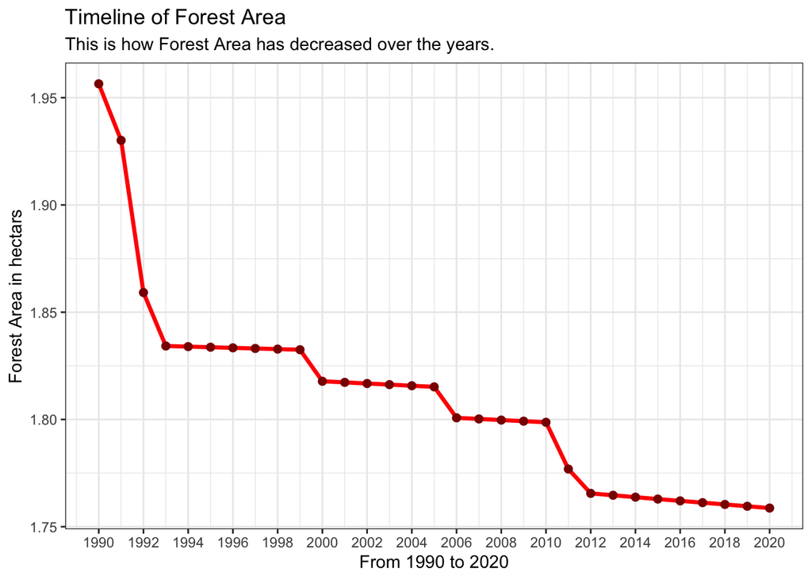

As seen in the above graph, the area of forest has only seen a decline over the past few decades. This gave us the motivation to look deeper into one the Global crisis. Deforestation has always been a vital concern of the world’s environment, and the direct response to the severity of the problem is through the change of forest land area. This report will focus on how the commodity market is related to deforestation and traded between countries to see which countries are the primary supplier and consumers of deforestation-related goods.

But, there are some datasets that are outdated (i.e., annual deforestation dataset, 1990 to 2015), with several missing values in critical variables (i.e entity, code, deforestation). These limitations will make it difficult for researchers to find meaningful results.

# 2 Data description

## 2.1 Data source

We have selected the data from the GitHub webpage of TidyTuesday (https://github.com/rfordatascience/tidytuesday/blob/master/data/2021/2021-04-06/readme.md), which talks about the drivers of deforestation over the years. We have chosen six datasets related to deforestation, and several variables are analyzed: forest area, deforestation, imported deforestation, exported deforestation, human food, animal food, processed, crop oil, and production.

## 2.2 Dataset source

The data is originally obtained from “Our World in Data”. And this article “Forests and Deforestation” is retrieved from: ‘https://ourworldindata.org/forests-and-deforestation’ and written by Hannah Ritchie and Max Roser (2021).

## 2.3 Data Cleaning

Although the data is gathered in a cleaned format, we found some minor issues with only one data set: annual-deforestation.csv.

The CSV file had 2 missing world’s continents North America and Antarctica. Since Antarctica is covered by permanent ice and snow leaving less than 1% available for colonization by plants and trees, we decided not to add the continent to the analysis. While with North America, we faced some issues like:

- The data set had less than half of the countries (8/23) mentioned from the continent.
- There were missing data of the US which is one of the major countries contributing significantly to the world’s deforestation rate.

There are some steps about what we did to wrangle the dataset into our desired format.

1. We created another data frame filtered with the countries available from the continent.
2. We calculated the cumulative mean for each year the countries went through deforestation.
3. Lastly, we added observations for each year according to the data structure and wrote the final CSV file to the data folder.

## 2.4 Structure of data

After the data cleaning, the description of some variables included in those datasets are presented in the table 2.1 below:

Table 2.1: Data description for variables included in data

| Variables | Class | Description |
| --- | --- | --- |
| entity | character | the country name |
| code | character | the country code |
| year(Forest area) | double | year from 1990 to 2020 |
| year(deforestation) | integer | year from 1990 to 2015 |
| year(Imported deforestation) | double | year from 2005 to 2013 |
| year(exported deforestation) | double | year from 2005 to 2013 |
| year(Soybean use) | double | year from 1961 to 2013 |
| year(Vegetable oil) | double | year from 1961 to 2014 |
| forest_area | double | the global forest area measured in hectares |
| Deforestation | double | the deforested area in hectares |
| imported_deforestation | double | each country’s imported deforestation, measured in hectares |
| exported_deforestation | double | each country’s exported deforestation, measured in hectares |
| human food | double | soybean use for human food (tempeh, tofu, etc) |
| animal feed | double | soybean used for animal food |
| processed | double | soybean processed into vegetable oil, biofuel, processed animal feed |
| crop_oil | character | crops that were used to produce vegetable oil |
| production | double | oil production in tonnes |

## 2.5 Proposed Research Questions:

1. How are forests distributed across the world and how much each region contributes to deforestation?
2. Who are the largest ‘importers’ and ‘exporters’ of deforestation?
3. Does higher production of commodities(palm oil/soybean) result in a higher deforestation rate?

# 3 Analysis and findings

## 3.1 How are forests distributed across the world and how much each region contributes to deforestation?

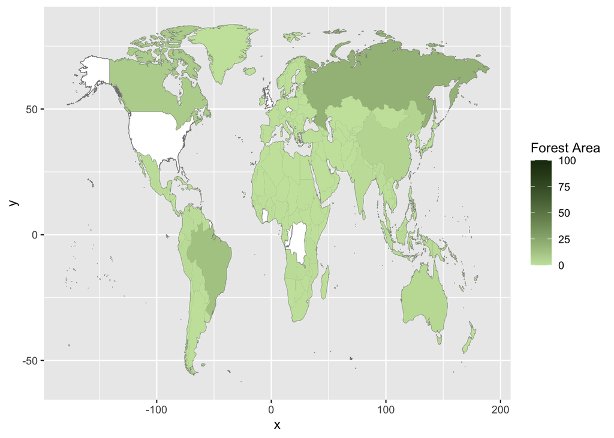

Figure 3.1: Forest area distibuted across the world

Through the above map, we can understand that Russia and Brazil dominate the world with larger forest areas. It also can be seen that China has the largest forest area in Asia. However, several observations are missing here for some countries, such as the United States.

The below table shows the deforestation rate among the continents of the world. It can be clearly seen through the line graph that though South America’s deforestation rate has seen a significant decrease over the years, it still outstands the other continents with the highest amount of deforestation in hectares.

[output not shown]

Interestingly, Africa doesn’t stand far behind and sees an increasing pace of deforestation and is the only country whose number soars high over the years. Even though the data set consists of some missing values for the continent, Africa still manages to share the average deforestation rate alongside South America. Intriguing, Europe’s graph exhibit some unusual increment and a sudden decrement in logging. While the rest of the continents see a fairly declined pattern over the years.

## 3.2 Who are the largest ‘importers’ and ‘exporters’ of deforestation?

Most deforestation occurs for the production of goods that are consumed within domestic markets. In this section, the amount of deforestation embedded in traded products between some countries is being analyzed, aiming to determine the major importers and exporters of deforestation-related consumed products across the world.

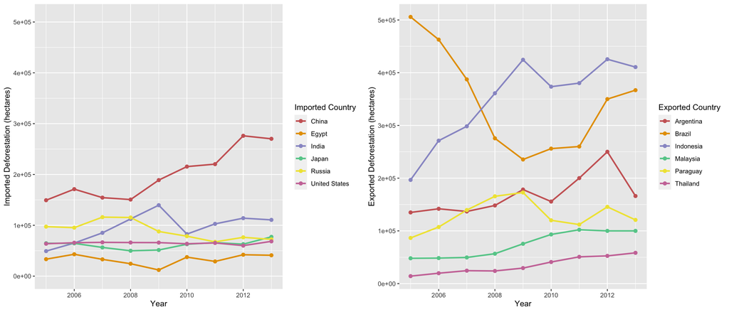

Figure 3.2: Exported and Imported Deforestation

The figure 3.2 above provides a general view of which country is the largest importer and exporter of deforestation. The x-axis shows the years from 2005 to 2013, while the y-axis represents the imported and exported deforestation measured by hectares.

It is clear that China is the largest importer of deforestation over this period. Also, Indonesia passed Brazil in near 2008 and has become the largest deforestation exporter.

Table 3.1: Deforestation Embedded In Exported And Imported Goods

| Exported Country | Code | 2005 | 2013 | Relative change (%) | Imported Country | Code | 2005 | 2013 | Relative change (%) |
| --- | --- | --- | --- | --- | --- | --- | --- | --- | --- |
| Indonesia | IDN | 196664.01 | 410700.47 | 108.833566 | China | CHN | 149357.92 | 270174.06 | 80.89035 |
| Brazil | BRA | 505810.02 | 366882.97 | -27.466251 | India | IND | 49251.57 | 110672.94 | 124.70946 |
| Argentina | ARG | 134980.07 | 166121.87 | 23.071405 | Japan | JPN | 64667.68 | 77276.91 | 19.49851 |
| Paraguay | PRY | 86591.25 | 120810.93 | 39.518635 | Russia | RUS | 97383.83 | 72298.53 | -25.75920 |
| Malaysia | MYS | 48045.77 | 99978.22 | 108.089549 | United States | USA | 63726.35 | 68427.87 | 7.37767 |
| Thailand | THA | 14184.09 | 58355.38 | 311.414336 | Egypt | EGY | 33345.75 | 41038.22 | 23.06883 |
| Vietnam | VNM | 13490.21 | 39150.13 | 190.211426 | South Korea | KOR | 25909.18 | 40224.71 | 55.25273 |
| Australia | AUS | 35067.82 | 37619.54 | 7.276522 | Brazil | BRA | 15707.33 | 37769.97 | 140.46076 |
| Zambia | ZMB | 10369.11 | 22684.26 | 118.767732 | Germany | DEU | 46834.53 | 36883.04 | -21.24819 |
| Nicaragua | NIC | 12543.55 | 13721.88 | 9.393926 | Italy | ITA | 45018.11 | 35308.85 | -21.56744 |

The above table 3.1 shows the major deforestation-related commodities exporter and importer and their relative percentage change of 2005 and 2013. Among all these countries, it can be seen that five exported countries and two imported countries have a significant increase of more than 100 %. Another interesting finding is that most exporters are low-income countries while most imported countries are high-income or upper-middle-income. Therefore, it is reasonable to say that the more affluent countries are more likely to contribute to deforestation in poorer countries.

## 3.3 Does higher production of commodities(palm oil/soybean) result in a higher deforestation rate?

To solve the problem, one needs to know about the root cause of the problem. Out of the three general classifications of the forest:

- Temperate forests (found across eastern North America and Eurasia).
- Tropical forests (common in areas near the equator, such as Southeast Asia, sub-Saharan Africa, and Central America).
- and the third Boreal forests, (found across Siberia, Scandinavia, Alaska and Canada).

The most concentrated deforestation occurs in tropical rainforests because they have the ability to provide considerably the most used commodities to the world. These commodities mainly consist of beef, oilseeds, soy, forestry items, and other edibles.

### 3.3.1 Soybean

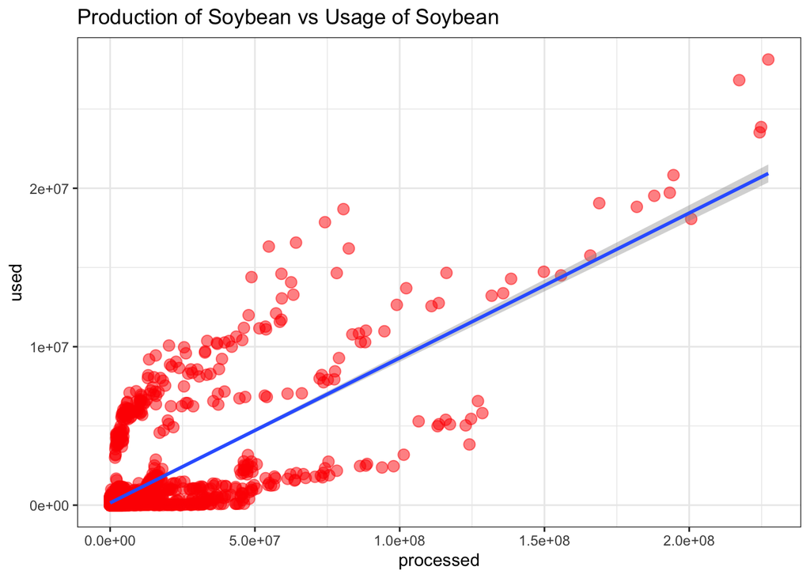

Figure 3.3: Production and Consumption of Soybean

|  | Country | Production in Tonnes | Human Usage in Tonnes | Animal Usage in Tonnes |
| --- | --- | --- | --- | --- |
| 1 | Africa | 648358 | 263585 | 35113 |
| 2 | Albania | 1660 | 0 |  |
| 3 | Algeria |  | 0 | 868 |
| 4 | Americas | 60234528 | 365151 | 1519736 |
| 5 | Angola |  | 1906 |  |
| 6 | Antigua and Barbuda |  | 0 |  |
| 7 | Argentina | 10283755 | 0 | 85113 |
| 8 | Armenia |  | 0 | 2136 |
| 9 | Asia | 23531604 | 6579321 | 1647566 |
| 10 | Asia, Central | 60318 | 136 | 28364 |

[output cut: 197 more lines]

Soybean production has seen an enormous amount of surge over the past 50 years. More than 70% of soybean is used to feed animals while approx 20% and 4% of the remaining soy is used for human food and industries respectively.

### 3.3.2 Vegetable Oil

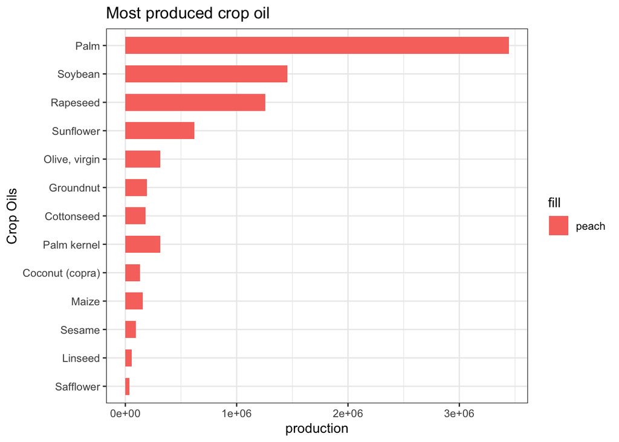

Figure 3.4: Most production in crop oil

According to the figure 3.4 above, it is obvious that the most productive crop oil is palm oil, followed by soybean oil and then rapeseed. We found it to be intriguing that how palm oil’s production outstands the rest of the vegetable oils so dominantly.

|  | Country | Production in Tonnes |
| --- | --- | --- |
| 1 | Afghanistan | 3366 |
| 2 | Africa | 302997 |
| 3 | Albania | 2402 |
| 4 | Algeria | 11607 |
| 5 | American Samoa | 78 |
| 6 | Americas | 1354906 |
| 7 | Angola | 11873 |
| 8 | Antigua and Barbuda | 13 |
| 9 | Argentina | 364253 |
| 10 | Armenia | 994 |

[output cut: 222 more lines]

From the table above, we can see that the highest producers of oil are Asian countries. Precisely the South Asian countries like Indonesia and Malaysia generates more than 60% of palm oil in the world. Being one of the small geographical areas in the world, these countries still manage to produce an enormous amount of vegetable oils.

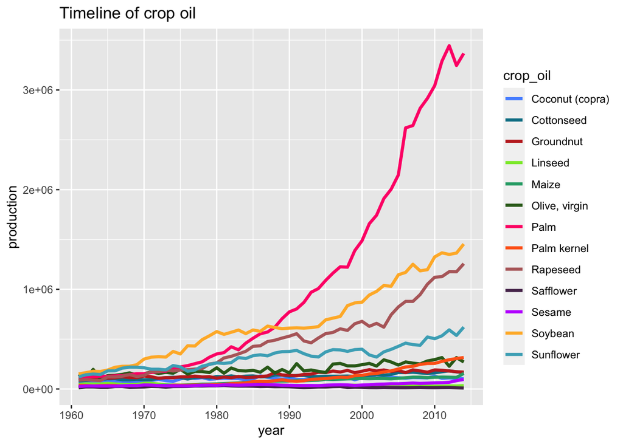

The line graph 3.5 demonstrates the timeline of various types of crop oil production from 1961 to 2014. It seems that the production of palm oil shows a significant upward trend and outstands other crop oil’s production. Since Palm oils are used in the production of almost every edible thing, there has a lot of demand than other oils. If there is higher demand then the farmers and producers will want to have more land for palm oil, leading to deforestation.